# M2.991_20241_PAC4-Enunciat_actualizat

**Implementació:** Avalueu el model amb les dades originals utilitzant exactitud, sensibilitat, especificitat, ROC-AUC i matriu de confusió.

```
6/6 ━━━━━━━━━━━━━━━━━━━━ 0s 15ms/step
CNN_For_full_data ROC-AUC: 0.7205555555555556
CNN_For_full_data Accuracy: 0.7105263157894737
CNN_For_full_data Sensitivity: 0.9111111111111111
CNN_For_full_data Specificity: 0.53
CNN_For_full_data Confusion Matrix:
[[53 47]
 [ 8 82]]
              precision    recall  f1-score   support

           0       0.87      0.53      0.66       100
           1       0.64      0.91      0.75        90

    accuracy                           0.71       190
   macro avg       0.75      0.72      0.70       190
weighted avg       0.76      0.71      0.70       190
```

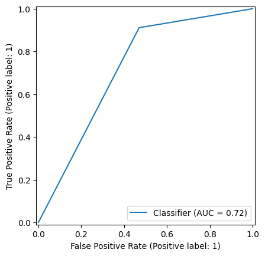

```python
evaluate_ensemble(model_original, X_valid_image_original, y_valid_total, "CNN_For_full_data")
```

**Implementació:** Avalueu el model amb les dades amb PCA utilitzant exactitud, sensibilitat, especificitat, ROC-AUC i matriu de confusió.

```
6/6 ━━━━━━━━━━━━━━━━━━━━ 0s 13ms/step
CNN_For_pca ROC-AUC: 0.6848935226264419
CNN_For_pca Accuracy: 0.6842105263157895
CNN_For_pca Sensitivity: 0.7065217391304348
CNN_For_pca Specificity: 0.6632653061224489
CNN_For_pca Confusion Matrix:
[[65 33]
 [27 65]]
              precision    recall  f1-score   support

           0       0.71      0.66      0.68        98
           1       0.66      0.71      0.68        92

    accuracy                           0.68       190
   macro avg       0.68      0.68      0.68       190
weighted avg       0.69      0.68      0.68       190
```

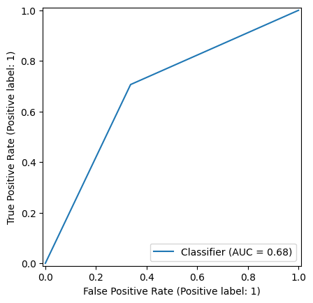

```python
evaluate_ensemble(model_pca, X_valid_image_pca, y_valid_PCA, "CNN_For_pca")
```

- 5.7. Anàlisis

**Anàlisi:** Analitza els resultats de les dues implementacions del model CNN personalitzat, una amb dades originals i l’altra amb dades transformades amb PCA.

- 5.8. **Comparativa entre CNN personalitzada i mètodes d'ensemble**

**Anàlisi:** Compara els resultats obtinguts amb la CNN personalitzada i els mètodes d'ensemble (Bagging, Boosting, Stacking i Cascading), tant amb les dades originals com amb les dades transformades mitjançant PCA. Identifica quins mètodes són més efectius en funció de les mètriques clau: Accuracy, Sensitivity, Specificity i ROC-AUC.

Crec que els metodes son una millor opcio per diversos motius, primer en general han donat millors resultats, però encara que optimitzesim molt les layer crec que la falta de poder explicar que fa el model i que les dades no estan pensades per ser utilitzades en una cnn jugan molt en contra d'utilitzar aquest tipus de models per aquest problema en concret, això s'ha vist especialment en les dades de pca on el model ha empitjotat molt.

- 5.9. **OPCIONAL** - Què és el *Transfer Learning*? (1 punt addicional)

El *Transfer Learning*, o aprenentatge per transferència, és una tècnica avançada dins del camp de la intel·ligència artificial i l'aprenentatge automàtic. La idea principal és senzilla però molt poderosa: aprofitar el coneixement adquirit per un model quan ha estat entrenat en una tasca per aplicar-lo a una altra tasca diferent però relacionada.

**Metàfora per entendre-ho** Imagina que aprens a tocar el piano. Una vegada has après les bases, com ara llegir partitures o coordinar les mans, aprendre a tocar un altre instrument, com el violí, serà més fàcil perquè moltes habilitats que has adquirit ja són aplicables. Això és exactament el que fa el *Transfer Learning* en l'àmbit dels models d'aprenentatge profund.

**Com funciona?**

1. **Model preentrenat**:
   - En el *Transfer Learning*, es comença amb un model ja entrenat en una gran quantitat de dades generals (com imatges de milers de categories diferents).
   - Aquest model ha après patrons generals (per exemple, identificar línies, formes i textures en imatges).
2. **Transferència de coneixement**:
   - Es reutilitzen les primeres capes del model preentrenat, que contenen aquest coneixement general.
   - Només cal ajustar (o afegir) les capes finals perquè el model pugui especialitzar-se en la nova tasca específica.
3. **Entrenament amb dades específiques**:
   - Amb un conjunt més petit de dades específiques de la tasca (com imatges de pacients amb o sense diabetis), el model s'entrena per refinar el coneixement i adaptar-se.

**Per què utilitzar el *Transfer Learning*?**

1. **Estalvi de temps i recursos**:
   - No cal entrenar un model des de zero, ja que el model preentrenat ja ha realitzat gran part de la feina d’aprenentatge.
   - Això redueix significativament el temps i els costos computacionals.
2. **Rendiment més alt amb dades limitades**:
   - Si només disposem d’un conjunt petit de dades específiques, el *Transfer Learning* ajuda a evitar problemes com el sobreajustament (*overfitting*), aprofitant el coneixement previ.
3. **Resultats robustos**:
   - Els models preentrenats ja han estat provats amb grans conjunts de dades, la qual cosa garanteix una base sòlida i generalitzable per treballar.

Exemple pràctic: Suposem que volem classificar si una imatge mostra un pacient amb diabetis o no. Podem utilitzar un model preentrenat com ResNet50 (que ha après a reconèixer patrons generals d’imatges) i adaptar-lo a la nostra tasca, sense necessitat d’entrenar-lo des de zero.

El *Transfer Learning* permet enfocar-nos en la nostra tasca específica sense perdre temps construint i entrenant un model completament nou. És com pujar a l'esquena d'un gegant per arribar més lluny!

- Adapteu un model de xarxa neuronal preentrenat (ResNet50) per a dades tabulars.
- Entreneu el model utilitzant les dades preprocessades i compareu el rendiment amb els mètodes d'ensemble.
- Avalueu el model utilitzant exactitud, sensibilitat, especificitat, ROC-AUC i matriu de confusió.

## **6. Optimització del Model i Sintonització d'Hiperparàmetres (2 punts)**

- 6.1. Sintonització d'hiperparàmetres amb GridSearchCV per al millor model d'ensemble

**Implementació:** Seleccioneu el model d'ensemble amb millor rendiment (per exemple, Stacking o Bagging). Definiu una graella d'hiperparàmetres rellevants. Per exemple: Per a Bagging: Nombre d'estimadors (n_estimators), mida màxima de mostres (max_samples); Per a Stacking: Models base i paràmetres associats als classificadors meta Utilitzeu GridSearchCV per explorar les combinacions possibles dels hiperparàmetres i seleccionar la millor configuració.

```python
estimators = [('dt',DecisionTreeClassifier()),('rf',RandomForestClassifier())]
model = StackingClassifier(estimators = estimators, final_estimator=LogisticRegression(max_iter = 500))
param_grid = {'rf__n_estimators': list(range(100,1000,200)),
          'dt__max_depth': list(range(4,11))}
grid = GridSearchCV(model, param_grid)
grid.fit(X_train_total, y_train_total)
```

```
GridSearchCV(estimator=StackingClassifier(estimators=[('dt',
                                                       DecisionTreeClassifier()),
                                                      ('rf',
                                                       RandomForestClassifier())],
                                          final_estimator=LogisticRegression(max_iter=500)),
             param_grid={'dt__max_depth': [4, 5, 6, 7, 8, 9, 10],
                         'rf__n_estimators': [100, 300, 500, 700, 900]})
```

```
StackingClassifier(estimators=[('dt', DecisionTreeClassifier(max_depth=4)),
                               ('rf', RandomForestClassifier())],
                   final_estimator=LogisticRegression(max_iter=500))
```

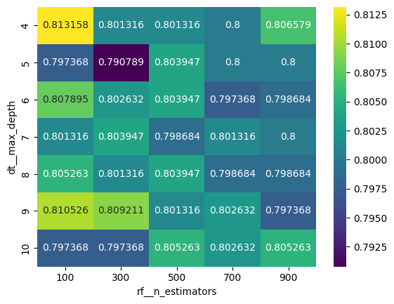

```python
print(grid.best_estimator_)
grid_results = pd.DataFrame(grid.cv_results_)
grid_results["dt__max_depth"] = grid_results["params"].apply(lambda x: x["dt__max_depth"])
grid_results["rf__n_estimators"] = grid_results["params"].apply(lambda x: x["rf__n_estimators"])
result = grid_results.pivot( index="dt__max_depth",columns='rf__n_estimators', values='mean_test_score')

sns.heatmap(result, annot=True, fmt="g", cmap='viridis')
plt.show()
```

- 6.2. Avaluació:

**Implementació:** Apliqueu el model amb els millors hiperparàmetres al conjunt de test. Compareu les mètriques del model optimitzat amb el model inicial.

**Consideracions finals**

- La sintonització d’hiperparàmetres sovint proporciona millores significatives, però pot ser computacionalment costosa. Prioritzeu els paràmetres més influents.
- Les mètriques d’avaluació del conjunt de test són claus per determinar si l’optimització ha millorat el model de manera generalitzada.
- Documenteu els hiperparàmetres seleccionats, els canvis en les mètriques i qualsevol observació rellevant per justificar les vostres decisions.

```
hyperparametes_stacking ROC-AUC: 0.8511666666666666
hyperparametes_stacking Accuracy: 0.7842105263157895
hyperparametes_stacking Sensitivity: 0.8777777777777778
hyperparametes_stacking Specificity: 0.7
hyperparametes_stacking Confusion Matrix:
[[70 30]
 [11 79]]
              precision    recall  f1-score   support

           0       0.86      0.70      0.77       100
           1       0.72      0.88      0.79        90

    accuracy                           0.78       190
   macro avg       0.79      0.79      0.78       190
weighted avg       0.80      0.78      0.78       190
```

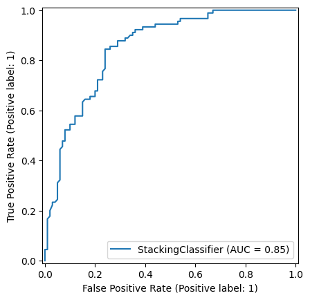

```python
estimators = [('dt',DecisionTreeClassifier(max_depth=4)),('rf',RandomForestClassifier(n_estimators=100))]
model = StackingClassifier(estimators = estimators, final_estimator=LogisticRegression(max_iter = 500))
model.fit(X_train_total, y_train_total)
evaluate_ensemble(model, X_valid_total, y_valid_total,"hyperparametes_stacking")
```

```python
y_pred = model.predict_proba(X_valid_total)
y_pred = y_pred[:,1]
y_pred = (y_pred>0.38).astype(np.uint8)
accuracy = accuracy_score(y_valid_total, y_pred)
cm = confusion_matrix(y_valid_total, y_pred)
sensitivity = cm[1, 1] / (cm[1, 0] + cm[1, 1])
specificity = cm[0, 0] / (cm[0, 0] + cm[0, 1])


print(f"{model_name} Accuracy: {accuracy}")
print(f"{model_name} Sensitivity: {sensitivity}")
print(f"{model_name} Specificity: {specificity}")
print(f"{model_name} Confusion Matrix:\n{cm}")
```

```
Cascading Accuracy: 0.7526315789473684
Cascading Sensitivity: 0.9333333333333333
Cascading Specificity: 0.59
Cascading Confusion Matrix:
[[59 41]
 [ 6 84]]
```

- 6.4. Anàlisis dels models optimitzat

**Anàlisi:** Valoreu l'impacte dels hiperparàmetres optimitzats en el conjunt de test comparant amb els resultats obtinguts abans de l'optimització.

Despres de mirar els hyperparametres no sembla que hagem millorat molt respecte el total però l'us de utilitzar un altre valor per decidir quan un valor es valid o no ha pugat molt la sensitivity sense vaixa molt la acuracy, També una opcio seria explorar aquest alogritma stacking amb altres sub algoritmes per veure si aixì podem obtenir millors resultats ja que canviant DecisionTreeClassifier per SVM potser tindriem millors resultats, però crec que tenir una sensivility del 93% es suficient, idealment la voldriem al 100% pero per obtenirla hauriem de baixar molt la accuracy, cosa que es podria parlar amb la persona que necesita el model, per saber fins a quin punt esta disposat a sacrificar la accuracy pel be de la sensitivity

Addicionalment és important remarcar:

**Importància de la Sensibilitat i l'Especificitat en Dades Mèdiques:**

En el context mèdic, la **sensibilitat** i l'**especificitat** són mètriques crucials que mesuren la capacitat d'un test diagnòstic per identificar correctament els casos positius i negatius, respectivament. Aquestes mètriques són especialment importants perquè ajuden a prevenir errors diagnòstics que podrien portar a tractaments incorrectes o mancats de tractament.

- **Sensibilitat** (també coneguda com a taxa de veritable positiu): Mesura la proporció de positius reals que són correctament identificats pel model. Una alta sensibilitat és crucial en condicions mèdiques on no detectar una malaltia (un fals negatiu) podria tenir conseqüències greus per al pacient. Per exemple, en el diagnòstic de càncer, una alta sensibilitat és essencial per assegurar que gairebé tots els pacients amb la malaltia són identificats per a un tractament precoç.
- **Especificitat** (també coneguda com a taxa de veritable negatiu): Mesura la proporció de negatius reals que són correctament identificats. Una alta especificitat és important per evitar falsos positius, que podrien portar a pacients sense la malaltia a sotmetre's a procediments invasius o estressants innecessaris. Per exemple, en el cribratge de malalties cardíaques, una alta especificitat redueix el nombre de pacients que rebran diagnòstics erronis de condicions que no tenen.

**Relació entre Sensibilitat i Especificitat:**

La relació entre sensibilitat i especificitat sovint s'involucra en un **compromís**; optimitzar un model per millorar la sensibilitat generalment reduirà la seva especificitat i viceversa. Això es deu a que l'augment de la sensibilitat implica abaixar el llindar per classificar un resultat com a positiu, el que incrementa el nombre de falsos positius i disminueix l'especificitat. A la inversa, augmentar l'especificitat solament augmenta el llindar, el que pot portar a més falsos negatius i disminuir la sensibilitat.

**Aplicacions en el Món Real:**

La selecció d'un model en un entorn mèdic depèn de la malaltia específica i del context del cribratge o diagnòstic. En malalties on les conseqüències de no detectar un cas positiu són greus, com en el càncer o infeccions greus, es pot preferir un model amb alta sensibilitat. En canvi, en condicions on un diagnòstic fals positiu podria portar a tractaments innecessaris o perjudicials, es preferirà un model amb alta especificitat.

La comprensió d'aquest equilibri i la seva correcta aplicació són essencials per desenvolupar eines diagnòstiques que no només són tècnicament competents sinó també èticament responsables, assegurant que els pacients reben el diagnòstic més precis possible amb les mínimes repercussions negatives.

```python
!pip install nbconvert
from google.colab import files
!jupyter nbconvert --to html "/content/drive/MyDrive/Colab Notebooks/pac4/M2.991_20241_PAC4-Enunciat_actualizat.ipynb"
files.download("/content/YourNotebookName.html")
```

[output not shown]

[output cut: 136 more lines]

[output not shown]

[output not shown]